# Python Matplotlib 教程

### 介绍人: 高鹏昺

# 1. Matplotlib 初探

## 1.1 Matplotlib 介绍

Matplotlib 是支持 Python 语言的开源绘图库，因为其支持丰富的绘图类型、简单的绘图方式以及完善的接口文档，深受 Python 工程师、科研学者、数据工程师等各类人士的喜欢。

Matplotlib 是一个优秀的2D&3D 图形库， 主要功能是生成科学用图，它的优点包括：

- 上手容易
- 支持 LaTeX 格式的标签与文本
- 能够很好地控制图中的每一样元素，包括图的大小与 DPI
- 高质量保存，支持多种格式, 包括 PNG, PDF, SVG, EPS, 与 PGF。
- 可交互的图形界面，支持生成无头部信息的图表文件（方便批处理）

Matplotlib 官方网址 http://matplotlib.org

**版本及文档页面**  
最新稳定版本 [2.1.0](http://matplotlib.org/2.1.0/contents.html)  
先前稳定版本 [2.0.2](http://matplotlib.org/2.0.2/contents.html)  
旧稳定版本 [1.5.3](http://matplotlib.org/1.5.3/index.html)

Matplotlib 教学视频:  
[Matplotlib Python3 数据可视化](https://morvanzhou.github.io/tutorials/data-manipulation/plt/)

## 1.2 Matplotlib 安装

**Windows & macOS**  
pip install matplotlib

**Linux**  
sudo apt-get install python-matplotlib

## 1.3 Matplotlib 快速绘图示例

导入matplotlib绘图模块**pyplot**

- **import matplotlib as mpl**
- **import matplotlib.pyplot as plt**
- **from matplotlib import pyplot as plt**

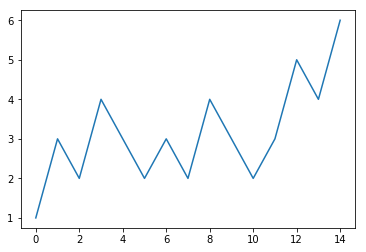

```python
import matplotlib.pyplot as plt

plt.plot([1,3,2,4,3,2,3,2,4,3,2,3,5,4,6])
plt.show()
```

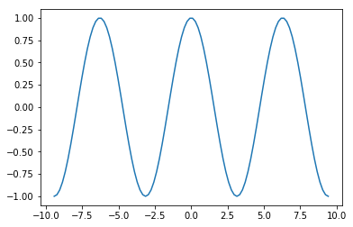

```python
from matplotlib import pyplot as plt
import numpy as np

x = np.linspace(-3*np.pi, 3*np.pi, 100)
y = np.cos(x)

plt.plot(x,y)
plt.show()
```

# 2. Matplotlib 2D图像绘制

| **方法** | **含义** |
| --- | --- |
| matplotlib.pyplot.**angle_spectrum** | 电子波谱图 |
| matplotlib.pyplot.**bar** | 柱状图 |
| matplotlib.pyplot.**barh** | 直方图 |
| matplotlib.pyplot.**broken_barh** | 水平直方图 |
| matplotlib.pyplot.**contourf** | 等高线图 |
| matplotlib.pyplot.**errorbar** | 误差线图 |
| matplotlib.pyplot.**hexbin** | 六边形图案 |
| matplotlib.pyplot.**hist** | 柱形图 |
| matplotlib.pyplot.**hist2d** | 水平柱形图 |
| matplotlib.pyplot.**imshow** | 图像显示 |
| matplotlib.pyplot.**pie** | 饼状图 |
| matplotlib.pyplot.**quiver** | 量场图 |
| matplotlib.pyplot.**scatter** | 散点图 |
| matplotlib.pyplot.**spcgram** | 光谱图 |
| matplotlib.pyplot.**subplot** | 子图 |

| **方法** | **含义** |
| --- | --- |
| matplotlib.pyplot.**annotate** | 绘制图形标注 |
| matplotlib.pyplot.**axhspan** | 绘制垂直或水平色块 |
| matplotlib.pyplot.**clabel** | 标注轮廓线 |
| matplotlib.pyplot.**fill** | 填充区域 |

## 2.1 线形图 plot

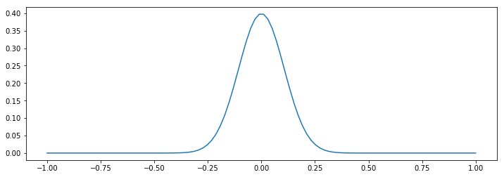

```python
import matplotlib.pyplot as plt
import numpy as np

X = np.linspace(-1, 1, 100)
y = (1/np.sqrt(2*np.pi))*np.exp(-(np.square(x))/2)

plt.figure(figsize=(12,4))
plt.plot(X,y)
plt.show()
```

### 线形图样式

| **参数** | **含义** |
| --- | --- |
| alpha | 设置线型的透明度，从0.0到1.0 |
| color | 设置线型的颜色 |
| fillstyle | 设置线型的填充样式 |
| linestyle | 设置线型的样式 |
| linewidth | 设置线型的宽度 |
| marker | 设置标记点的样式 |

### 颜色

| **color=参数** | **含义** |
| --- | --- |
| b | 蓝色 |
| g | 绿色 |
| r | 红色 |
| w | 白色 |
| m | 洋红色 |
| y | 黄色 |
| k | 黑色 |

### 线型

| **linestyle=参数** | **含义** |
| --- | --- |
| '-' | 默认实线 |
| '--' | 虚线 |
| '-.' | 间断线 |
| ':' | 点状线 |

### 点标记样式

| **marker=参数** | **含义** |
| --- | --- |
| '.' | 实心点 |
| ',' | 像素点 |
| 'o' | 空心点 |
| 'x' | X形点 |
| '+' | +形点 |
| '*' | 五角星点 |
| 'p' | 五角形点 |

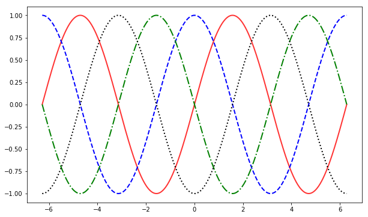

```python
import matplotlib.pyplot as plt
import numpy as np

X = np.linspace(-2*np.pi, 2*np.pi, 1000)
y1 = np.sin(X)
y2 = np.cos(X)
y3 = - np.sin(X)
y4 = - np.cos(X)

plt.figure(figsize=(10,6))
plt.plot(X, y1, color='r', linestyle='-', linewidth=2, alpha=0.8)
plt.plot(X, y2, color='b', linestyle='--', linewidth=2)
plt.plot(X, y3, color='g', linestyle='-.', linewidth=2)
plt.plot(X, y4, color='k', linestyle=':', linewidth=2)

plt.show()
```

### 绘图样式调整

#### 标题(title)、坐标轴标签(label)

正常显示中文需添加  
plt.rcParams['font.sans-serif']=['SimHei']

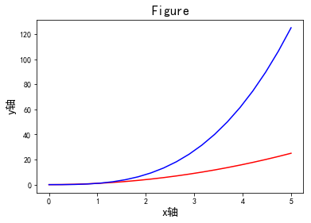

```python
plt.rcParams['font.sans-serif']=['SimHei'] #用来正常显示中文标签
plt.rcParams['axes.unicode_minus']=False #用来正常显示负号

x = np.linspace(0,5,20)
y1 = x**2
y2 = x**3

plt.figure()
plt.plot(x,y1,'r')
plt.plot(x,y2,'b')

plt.title('Figure', fontsize=16)
plt.xlabel('x轴', fontsize=14)    # 设置横轴标签
plt.ylabel('y轴', fontsize=14)    # 设置纵轴标签

plt.show()
```

#### 坐标轴范围

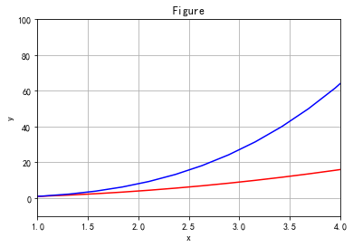

```python
x = np.linspace(0,5,20)
y1 = x**2
y2 = x**3

plt.figure()
plt.plot(x,y1,'r')
plt.plot(x,y2,'b')

plt.title('Figure')
plt.xlabel('x')    # 设置横轴标签
plt.ylabel('y')    # 设置纵轴标签
plt.xlim((1,4))
plt.ylim((-10,100))
plt.grid()

plt.show()
```

#### 坐标轴刻度

[figure not shown]

```python
x_ticks = np.arange(0, 5, 0.5)
y_ticks = np.arange(-10, 120, 10)

x = np.linspace(0,5,20)
y1 = x**2
y2 = x**3

plt.figure()
plt.plot(x,y1,'r')
plt.plot(x,y2,'b')

plt.title('Figure')
plt.xlabel('x')    # 设置横轴标签
plt.ylabel('y')    # 设置纵轴标签
plt.xlim((1,4))
plt.ylim((-10,100))
plt.xticks(x_ticks)
plt.yticks(y_ticks)
plt.grid()

plt.show()
```

#### 图例

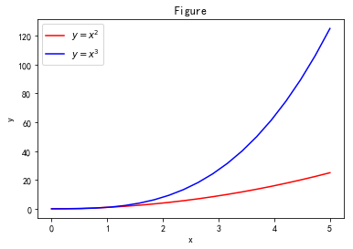

```python
x = np.linspace(0,5,20)
y1 = x**2
y2 = x**3

plt.figure()
plt.plot(x,y1,'r', label='$y=x^2$')
plt.plot(x,y2,'b', label='$y=x^3$')

plt.title('Figure')
plt.xlabel('x')    # 设置横轴标签
plt.ylabel('y')    # 设置纵轴标签

plt.legend()
plt.show()
```

#### 极坐标

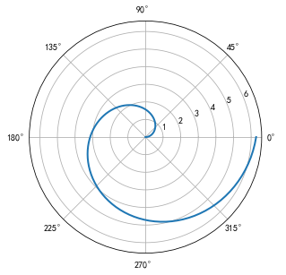

```python
fig = plt.figure(figsize=(6,6))
ax = fig.add_axes([0.0,0.0,0.6,0.6], polar=True)
t = np.linspace(0,2*np.pi,100)
ax.plot(t,t,lw=2)

plt.show()
```

## 2.2 散点图 scatter

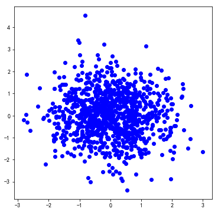

```python
X = np.random.normal(0,1,1000)
y = np.random.normal(0,1,1000)

plt.figure(figsize=(6,6))
plt.scatter(X,y,c='b')
plt.show()
```

### 散点图样式

| **参数** | **含义** |
| --- | --- |
| s | 散点大小 |
| c | 散点颜色 |
| marker | 散点样式 |
| cmap | 定义多类别散点的颜色 |
| alpha | 点的透明度 |
| edgecolors | 散点边缘颜色 |

```
D:\Program Soft\Anaconda\Anaconda3\lib\site-packages\matplotlib\collections.py:877: RuntimeWarning: invalid value encountered in sqrt
  scale = np.sqrt(self._sizes) * dpi / 72.0 * self._factor
```

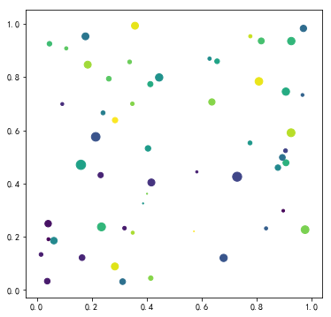

```python
x = np.random.rand(100)
y = np.random.rand(100)
colors = np.random.rand(100)
size = np.random.normal(10,40,100)

plt.figure(figsize=(6,6))
plt.scatter(x, y, s=size, c=colors)
plt.show()
```

## 2.3 柱形图 bar

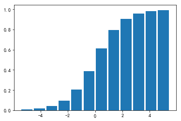

```python
X = np.linspace(-5, 5, 12)
y = 1 / (1 + np.exp(-X))
plt.bar(X,y)
plt.show()
```

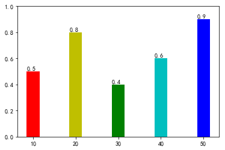

```python
x_bar = [10, 20, 30, 40, 50]
y_bar = [0.5, 0.8, 0.4, 0.6, 0.9]

plt.figure(figsize=(6,4))
bars = plt.bar(x_bar, y_bar, color='rygcb', label=x_bar, width=3)
plt.ylim(0.0, 1.0)

for i, rect in enumerate(bars):
    x_test = rect.get_x()
    y_test = rect.get_height() + 0.01
    plt.text(x_test, y_test, '%.1f' % y_bar[i])  # 标注文字

plt.show()
```

## 2.4 饼状图 pie

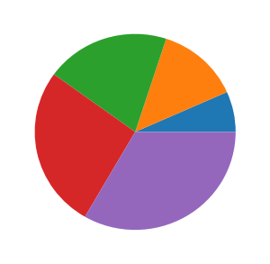

```python
Z = [1,2,3,4,5]

plt.figure(figsize=(5,5))
plt.pie(Z)
plt.show()
```

| **参数** | **含义** |
| --- | --- |
| s | 各类别占比大小 |
| c | 各类别颜色 |
| labels | 各类别标签 |
| explode | 各类别偏移半径 |
| shadow | 是否有阴影 |

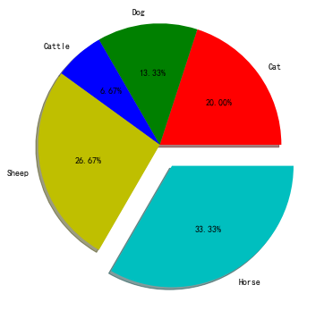

```python
labels = ['Cat', 'Dog', 'Cattle', 'Sheep', 'Horse']  # 各类别标签
colors = ['r', 'g', 'b', 'y', 'c']  # 各类别颜色
size = [3, 2, 1, 4, 5]  # 各类别占比
explode = (0.0, 0.0, 0.0, 0.0, 0.2)  # 各类别偏移半径

plt.figure(figsize=(6,6))
plt.pie(size, colors=colors, explode=explode, labels=labels, shadow=True, autopct='%1.2f%%')
plt.axis('equal')
plt.show()
```

## 2.5 等高线图 contourf

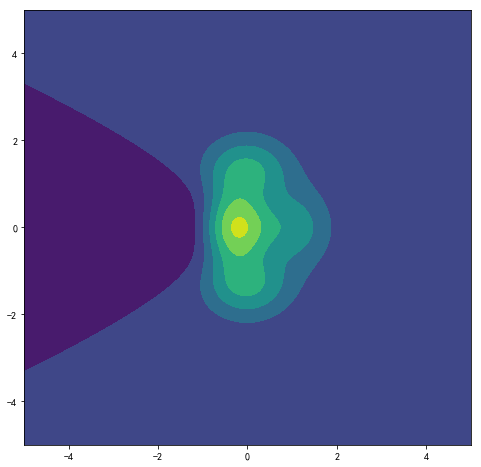

```python
x = np.linspace(-5,5,500)
y = np.linspace(-5,5,500)

X, Y = np.meshgrid(x,y)
Z = (1-X/2+X**3+Y**4) * np.exp(-X**2-Y**2)

plt.figure(figsize=(8,8))
plt.contourf(X,Y,Z)
plt.show()
```

## 2.6 量场图 quiver

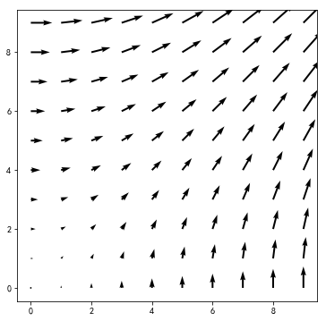

```python
X, y =np.mgrid[0:10, 0:10]

plt.figure(figsize=(6,6))
plt.quiver(X, y)
plt.show()
```

## 2.7 矩阵热力图

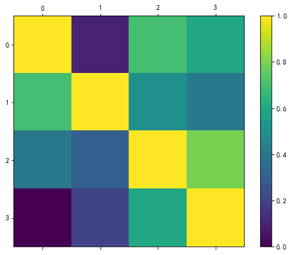

```python
M = np.matrix([[1, 0.1, 0.7, 0.6],
              [0.7, 1, 0.5, 0.4],
              [0.4, 0.3, 1, 0.8],
              [0, 0.2, 0.6, 1]])

fig = plt.figure(figsize=(8,6))
ax = fig.add_subplot(111)
cax = ax.matshow(M, vmin=0, vmax=1)

fig.colorbar(cax)
ticks = np.arange(0,9,1)
plt.show()
```

## 2.8 图片显示 imshow

[figure not shown]

```python
import matplotlib.pyplot as plt
from PIL import Image

image = Image.open('./Figure/Galaxy.jpg')

plt.figure(figsize=(12,8))
plt.title('Galaxy')
plt.imshow(image)
plt.show()
```

## 2.9 子图绘制 subplot

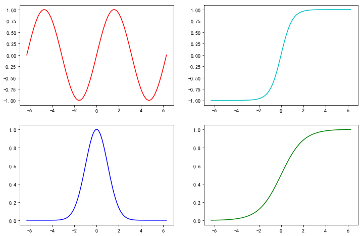

```python
x = np.linspace(-2*np.pi, 2*np.pi, 100)

y1 = np.sin(x)
y2 = np.tanh(x)
y3 = np.exp(-(x**2)/2)
y4 = 1/(1+np.exp(-x))

plt.figure(figsize=(12,8))

# 子图1
plt.subplot(2,2,1)
plt.plot(x, y1, 'r')

# 子图2
plt.subplot(2,2,2)
plt.plot(x, y2, 'c')

# 子图3
plt.subplot(2,2,3)
plt.plot(x, y3, 'b')

# 子图4
plt.subplot(2,2,4)
plt.plot(x, y4, 'g')

plt.show()
```

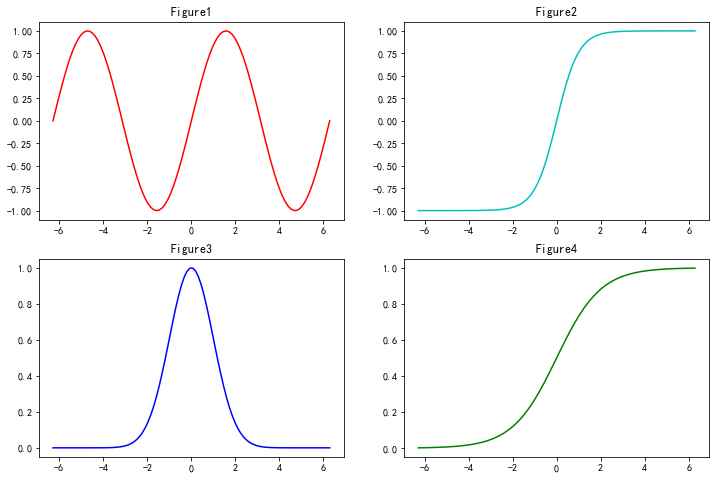

```python
fig, axes = plt.subplots(2,2, figsize=(12,8))

axes[0,0] = plt.subplot(221)
axes[0,0].set_title("Figure1")
axes[0,0].plot(x, y1, 'r')

axes[0,1] = plt.subplot(222)
axes[0,1].set_title("Figure2")
axes[0,1].plot(x, y2, 'c')

axes[1,0] = plt.subplot(223)
axes[1,0].set_title("Figure3")
axes[1,0].plot(x, y3, 'b')

axes[1,1] = plt.subplot(224)
axes[1,1].set_title("Figure4")
axes[1,1].plot(x, y4, 'g')

plt.show()
```

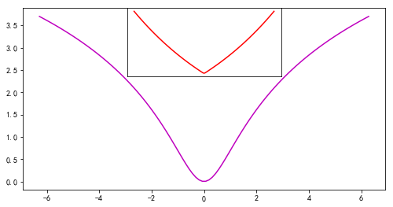

```python
x = np.linspace(-2*np.pi, 2*np.pi, 100)

y1 = np.log(x**2+1)
y2 = np.exp(abs(x*2)/20)

plt.figure(figsize=(8,4))
# 大图
plt.axes([.0, .0, .8, .8])
plt.plot(x, y1, 'm')

# 小图
plt.axes([.23, .5, .34, .3])  # 左边距，上边距，长度，高度
plt.plot(x, y2, 'r')
plt.xticks([])
plt.yticks([])

plt.show()
```